# Discrete characters exercise

Alex Faidiga

February 17, 2020

Loading in data from Smith and Brown’s (2017) huge tree of angiosperms, downloaded from https://github.com/FePhyFoFum/big_seed_plant_trees/releases. Both of these trees are built with GenBank data, but they differ in what tree is used as a “backbone”. The GBOTB tree uses Open Tree of Life data, and the GBMB uses data from Mallagón et al. (2015).

```r
GBOTB_tree <- read.tree("GBOTB.tre")
GBMB_tree <- read.tree("GBMB.tre")
ALLMB_tree <- read.tree("ALLMB.tre")
```

I’ll create a function that isolates a clade from the giant tree by identifying the node with the MRCA of two species provided to the function:

```r
clade_finder <- function(species1, species2, tree){
  viola_node<-fastMRCA(tree,species1,species2)   #identifies the most recent node where these two species shared a common ancestor
  viola_clade<-extract.clade(tree, viola_node) #extracts and creates a new tree for a clade based on the MRCA node identified
plot.phylo(viola_clade, cex = 0.3, type = "fan")
print(Ntip(viola_clade))
}

clade_finder("Viola_pubescens", "Viola_rostrata", GBOTB_tree)
```

```
## [1] 79
```

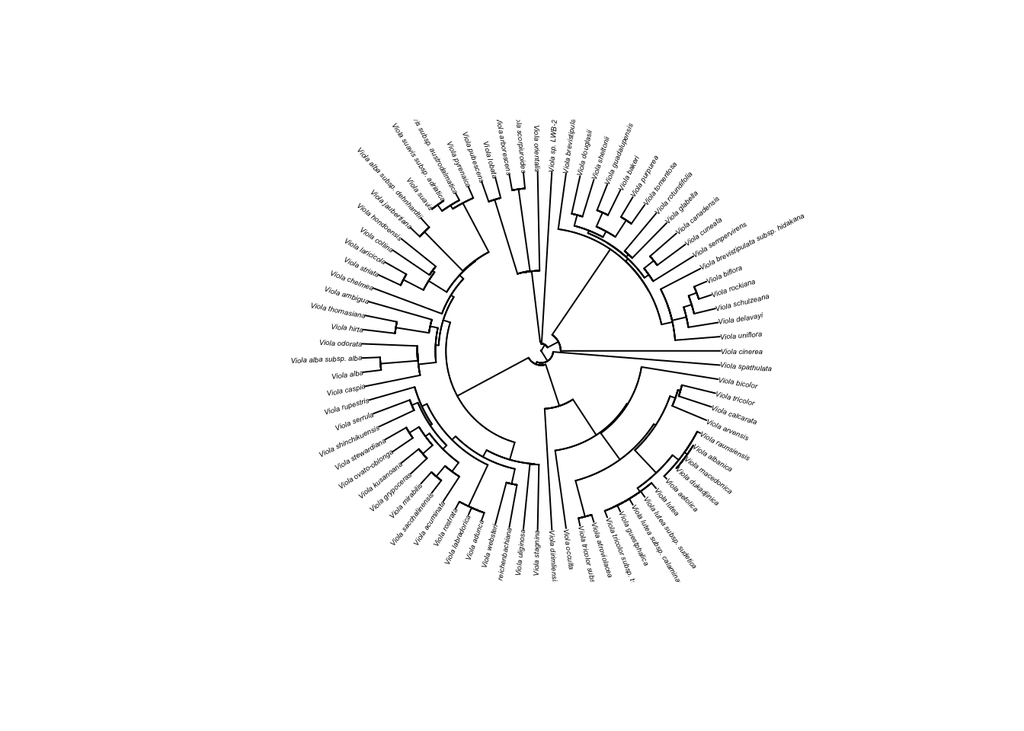

```
## [1] 79
```

```r
clade_finder("Viola_pubescens", "Viola_rostrata", GBMB_tree)
```

Now I have a clade of violets so I know the data are ok, but it’s not necessarily a meaningful clade. Between the two large trees, it looks like the clades I extracted have the same topology and number of tips.

Now, I’ll extract all violets from the large tree using genbank data (GBMB_tree and GBOTB_tree) and plot them.

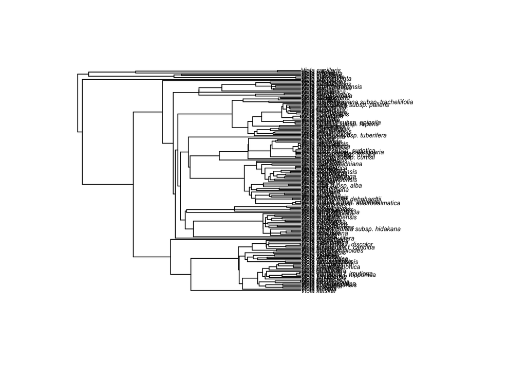

```r
# length(GBMB_tree$tip.label)
# length(GBOTB_tree$tip.label) #this tree has 7 more tips

all_tips_GBMB <- GBMB_tree$tip.label
all_tips_GBOTB <- GBOTB_tree$tip.label

viola_tips_GBMB <- all_tips_GBMB[grepl("Viola_", fixed = TRUE, GBMB_tree$tip.label)]
viola_tips_GBOTB <- all_tips_GBOTB[grepl("Viola_", fixed = TRUE, GBOTB_tree$tip.label)]

# length(viola_tips_GBMB)
# length(viola_tips_GBOTB) #same for both; 173 viola spp.

viola_node<-getMRCA(GBMB_tree, viola_tips_GBMB)
viola_tree<-extract.clade(GBMB_tree, viola_node)

plot(viola_tree, cex = 0.5)
```

```r
#write to PDF and open using preview
pdf(file="~/Desktop/phylometh/viola_tree1.pdf", width=20, height=20)

  plot(viola_tree, cex = 0.5, type = "fan")

system("open -a Preview.app ~/Desktop/phylometh/viola_tree1.pdf")
dev.off()
```

Another way to extract species of interest and build a tree if they are paraphyletic:

```r
viola_tree2 <- drop.tip(GBMB_tree, GBMB_tree$tip.label[!(GBMB_tree$tip.label %in% viola_tips_GBMB)])

pdf(file="~/Desktop/viola_tree2.pdf", width=20, height=20)

  plot(viola_tree2, type = "fan", cex = 1)

dev.off()
```

```r
system("open ~/Desktop/viola_tree2.pdf")
```

### It’s critically important to LOOK at what you have. Are there weird values? Has the match between taxa and state gone correctly? Do you think you have binary data, but there’s actually only state 1? Especially as data sets grow (yay), and are assembled using scripts rather than by error-prone, non-reproducable hands (double yay), scientists are increasingly less likely to deeply look at our data. That’s bad – don’t be that person.

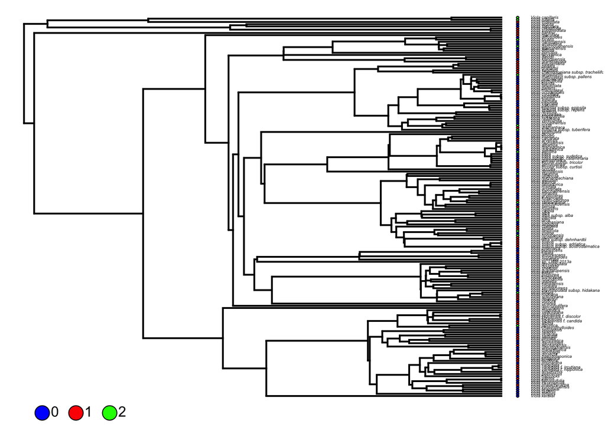

```r
VisualizeData <- function(phy, data) {
  fmode<-as.factor(setNames(data[,1],rownames(data)))
  trait1 <- unique(data[,1])[1]
  trait2 <- unique(data[,1])[2]
  trait3 <- unique(data[,1])[3]
  dotTree(phy, fmode, colors=setNames(c("blue","red", "green"),
    c(paste(trait1), paste(trait2), paste(trait3))),ftype="i", fsize = 0.3) #plot the discrete character on the phylogeny

}

#Create random data (in data frame form to work with this function) for viola since I don't have any:
species_list <- viola_tree$tip.label
viola_trait_012 <- rbinom(n=173, size=2, prob=0.3)
viola_data <- data.frame(species_list, viola_trait_012, row.names = 1)
VisualizeData(viola_tree, viola_data)
```

```r
# pdf(file="~/Desktop/viola_tree_traits.pdf", width=20, height=20)
#
# VisualizeData(viola_tree, viola_data)
#
# dev.off()
# system("open ~/Desktop/viola_tree_traits.pdf")
```

Test with another data set:

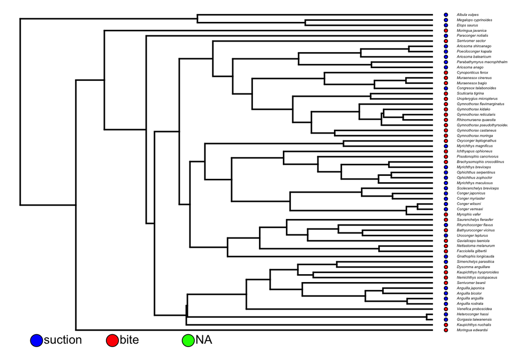

```r
eel_tree<-read.tree("elopomorph.txt")
eel_data<-read.csv("elopomorph.csv",row.names=1)

VisualizeData(eel_tree, eel_data)
```

```r
#yay! it works!
```

**NOTE: this function works for data frames where each row name is a species and there is a column for discrete trait data, where each species has a given value for that trait. Trait value can be binary or a string.**

### First, let’s use parsimony to look at ancestral states:

```r
viola_binary_trait <- rbinom(n=173, size=2, prob=0.5)
viola_data <- matrix(viola_binary_trait, nrow = length(species_list), ncol = 1, dimnames = list(species_list))

cleaned.discrete.phyDat <- phyDat(data = viola_data, type="USER", levels = c("0","1", "2")) #phyDat is a data format used by phangorn

anc.p <- phangorn::ancestral.pars(viola_tree, cleaned.discrete.phyDat)
plotAnc(tree = viola_tree, data = anc.p, i = 1, cex.pie = 0.2, cex = 0.3, type = "fan")


# pdf(file="~/Desktop/anc.states.parsimony.pdf", width=20, height=20)
#
# plotAnc(tree = viola_tree, data = anc.p, i = 1, cex.pie = 0.2, cex = 0.3, type = "fan")
#
# dev.off()
# system("open -a Preview.app ~/Desktop/ancestral.states.pdf")
```

[output not shown]

### Now, plot the likelihood estimates.

```r
anc.ml <- ancestral.pml(pml(tree = viola_tree, data = cleaned.discrete.phyDat), type="ml")

plotAnc(tree = viola_tree, data = anc.ml, i = 1, cex.pie = 0.2, cex = 0.7, type = "fan")

# pdf(file="~/Desktop/anc.states.ML.pdf", width=20, height=20)
#
# plotAnc(tree = viola_tree, data = anc.ml, i = 1, cex.pie = 0.2, cex = 0.7, type = "fan")
#
# dev.off()
# system("open -a Preview.app ~/Desktop/anc.states.ML.pdf")
```

[output not shown]

### Why does it differ from parsimony?

Parsimony is estimating the ancestral states based on the least amount of changes possible, while ML is finding the ancestral states that maximize the likelihood of the data on the tree.

### What does uncertainty mean?

Uncertainty in this case has to do with our uncertainty in the character state at a given node.

### Now, to the biological questions. For many of these, corHMM will be a useful package. Do the following analyses:

#### How can you estimate transition rates between states? Do it.

```r
species_list <- viola_tree$tip.label
viola_binary_trait2 <- rbinom(n=173, size=1, prob=0.2)
viola_data2 <- matrix(c(species_list, viola_binary_trait2), nrow=173, ncol=2, byrow=F)

mm = rbind(c(NA, 1), c(2, NA))

cor.rates <- rayDISC(phy = viola_tree, data = viola_data2, ntraits = 1, node.states = "marginal", rate.mat = mm)
```

```
## State distribution in data:
## States:  0   1
## Counts:  134 39
```

```
## Initializing...
## Finished. Beginning thorough search...
## Finished. Inferring ancestral states using marginal reconstruction.
```

```r
cor.rates
```

```
##
## Fit
##       -lnL      AIC     AICc ntax
##  -92.80234 189.6047 189.6753  173
##
## Rates
##     0        1
## 0  NA 29.42201
## 1 100       NA
##
## Arrived at a reliable solution
```

#### How could you examine if transition rates are equal?

The “fit” output from rayDISC tells you the transition rates between states. Because I supplied a matrix indicating that I think the rates would be different, it provided two different parameter estimates for the transition from 0 to 1 and 1 to 0.

#### Think about the Lewis (2001) MKV model. Are your traits all variable? Will using this make sense for your data? Try using it. Do results change? How could you test order of state evolution?

Because the MKV model uses discrete traits to estimate branch lengths using likelihood, using only variable characters (without correcting for acquisition bias) leads to overestimation of rates of evolution and therefore less accurate estimates of branch lengths.

```r
#simulating more traits, because it needs more than one:
species_list <- viola_tree$tip.label
viola_binary_trait2 <- rbinom(n=173, size=1, prob=0.2)
viola_binary_trait3 <- rbinom(n=173, size=1, prob=0.7)
viola_binary_trait4 <- rbinom(n=173, size=1, prob=0.4)


viola_data3 <- data.frame(viola_binary_trait2, viola_binary_trait3, viola_binary_trait4, row.names = species_list)
names(viola_data3)
```

```
## [1] "viola_binary_trait2" "viola_binary_trait3" "viola_binary_trait4"
```

```r
# MKV <- lewisMkv(phy = viola_tree, data = viola_data3, ncores = 2)
#
# par(mfcol = (c(1,2)))
# plot.phylo(viola_tree, cex = 0.2)
# plot.phylo(MKV$phy, cex = 0.2)

# pdf(file="~/Desktop/viola_tree_traits.pdf", width=20, height=20)
#
# par(mfcol = (c(1,2)))
# plot.phylo(viola_tree, cex = 0.2)
# plot.phylo(MKV$phy, cex = 0.2)
#
# dev.off()
# system("open ~/Desktop/viola_tree_traits.pdf")
```

I got MKV to work, but for some reason it is not working in Rmarkdown. The tree I got from it has much different branch lengths than the tree I provided it (much shorter branches).